# 과제#5 MLE2

## 202STG18 이재빈

```r
library(tidyverse)
```

```r
library(optimx)
```

```r
library(ggpmisc)
library(gridExtra)
```

# Part1. Smoking and Mortality: 흡연과 수명의 연관성 분석

- Data: Canadian Veteran Survey
- Objective: NonSmoker와 Cigarette Smoker의 생명표(life table)를 작성하여 차이 비교

## (a) NonSmoker & Cigarette 그룹의 사망확률 산점도

```r
smoker <- read.csv("smoker.csv", header=T)
colnames(smoker) <- c("age","x","pop.non","death.non","pop.cig","death.cig")

# tqx: 사망자수 / 인구수
non<-smoker %>% transmute(x,pop=pop.non,death=death.non,tqx=death.non/pop.non,ln=log(-log(1-tqx)))
cigar<-smoker %>% transmute(x,pop=pop.cig,death=death.cig,tqx=death.cig/pop.cig,ln=log(-log(1-tqx)))

smoking<-rbind(non,cigar)
smoking$smoke<-c(rep("nonsmoking",9),rep("smoking",9))
```

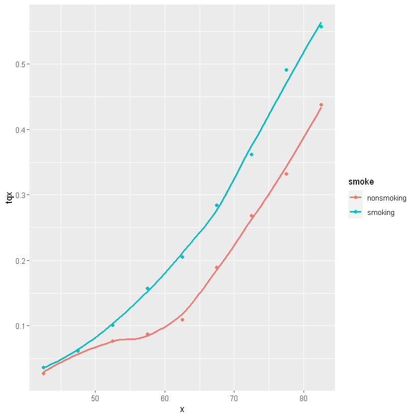

```r
ggplot(smoking,aes(x,tqx,group=smoke,colour=smoke))+geom_point()+geom_smooth(se=F)
```

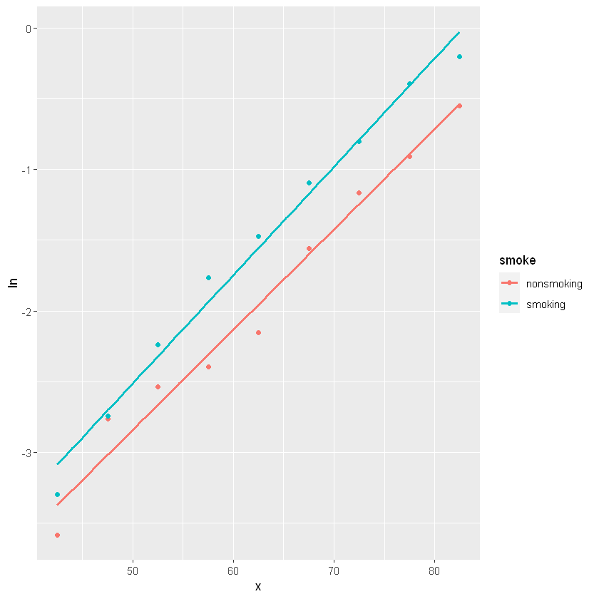

```r
ggplot(smoking,aes(x,ln,group=smoke,colour=smoke))+geom_point()+geom_smooth(method="lm",se=F)
```

- 산점도를 보았을 때 나이가 많아질수록 사망확률이 크게 나타났다.
- 또한 비흡연자와 흡연자의 그룹을 비교했을 때 흡연자의 사망확률이 더 높았으나,  
  나이가 많아질수록 비흡연자와의 차이가 더 크게 나타나고 있다.
- (x, tqx)의 산점도를 보았을 때 지수형태로 따르는 것을 보이고,
- (x,ln[-ln(1-tqx)])으로 보았을 때 선형을 따르고 있다.
- 따라서 Gompertz 법칙이 성립함을 알 수 있다.

## (b) a,b 추정

### 방법1: OLS 추정값 (a*, b) 이용

```r
lm_non<-lm(ln~x,data=non)
astar_non<-summary(lm_non)$coefficients[[1]]
b_non<-summary(lm_non)$coefficients[[2]]
a_non<-astar_non-log((exp(b_non*6)-1)/b_non)
c(astar_non,b_non)
```

1. -6.38559948241774

2. 0.0708662465563469

```r
lm_cigar<-lm(ln~x,data=cigar)
astar_cigar<-summary(lm_cigar)$coefficients[[1]]
b_cigar<-summary(lm_cigar)$coefficients[[2]]
a_cigar<-astar_cigar-log((exp(b_cigar*6)-1)/b_cigar)
c(astar_cigar,b_cigar)
```

1. -6.33850825252294

2. 0.0765182722782982

### 방법2: Logistic Regression을 이용한 MLE (alpha, beta) 이용

```r
#Logistic Regression
lm_gompit_non<-glm(death/pop~x,data=non,family=binomial(link="cloglog"),weights=pop)
alpha_non<-summary(lm_gompit_non)$coefficients[[1]]
beta_non<-summary(lm_gompit_non)$coefficients[[2]]
```

```r
lm_gompit_cigar<-glm(death/pop~x,data=cigar,family=binomial(link="cloglog"),weights=pop)
alpha_cigar<-summary(lm_gompit_cigar)$coefficients[[1]]
beta_cigar<-summary(lm_gompit_cigar)$coefficients[[2]]
```

```r
#MLE
non_mle<-function(v) {
  z=v[1]+v[2]*non$x
  Gz=1-exp(-exp(z))
  sum(log(dbinom(non$death,non$pop,Gz)))
}
```

```r
cigar_mle<-function(v) {
  z=v[1]+v[2]*cigar$x
  Gz=1-exp(-exp(z))
  sum(log(dbinom(cigar$death,cigar$pop,Gz)))
}
```

```r
result_non<-optimx(par=c(-6,0.07),non_mle,control=list(all.methods=T,maximize=T,save.failures=TRUE,trace=0))
```

```
Maximizing -- use negfn and neggr
```

```r
result_cigar<-optimx(par=c(-6,0.07),cigar_mle,control=list(all.methods=T,maximize=T,save.failures=TRUE,trace=0))
```

```
Maximizing -- use negfn and neggr
```

```r
mle_non<-c(result_non[3,1],result_non[3,2])
mle_cigar<-c(result_cigar[3,1],result_cigar[3,2])
```

```r
mle_a_non<-mle_non[1]-log((exp(mle_non[2]*6)-1)/mle_non[2])
mle_a_cigar<-mle_cigar[1]-log((exp(mle_cigar[2]*6)-1)/mle_cigar[2])
```

```r
c(mle_non,mle_a_non)
```

1. -6.57972252668211

2. 0.0735122123722365

3. -8.60011159984517

```r
c(mle_cigar,mle_a_cigar)
```

1. -6.27921402555846

2. 0.0764406501756969

3. -8.30904489170963

- OLS의 경우 pdf 계산이 불필요하므로 계수 추정이 훨씬 간단하다.
- MLE의 경우 훨씬 정확하게 계수를 추정할 수 있다는 장점이 있다.  
  하지만 복잡한 계산이 필요하며, 적절한 초기값 설정 또한 필요하다.

## (c) lifetable

```r
life.non<-data.frame(t=seq(0,80,by=1),x=seq(20,100,by=1))
life.non<-cbind(life.non,lx=rep(NA,nrow(life.non)),ex=rep(NA,nrow(life.non)))

for (i in 2:nrow(life.non)) {
  life.non[1,"lx"]<-10^5
  life.non[i,"lx"]<-10^5*exp(-exp(mle_a_non+mle_non[2]*life.non[1,"x"])*(exp(mle_non[2]*life.non[i,"t"])-1)/mle_non[2])
  for (j in 2:nrow(life.non)) {
    life.non[j-1,"ex"]<-0.5+sum(life.non[j:nrow(life.non),"lx"])/life.non[j-1,"lx"]
    life.non[nrow(life.non),"ex"]<-0.5
  }
}
```

```r
life.cigar<-data.frame(t=seq(0,80,by=1),x=seq(20,100,by=1))
life.cigar<-cbind(life.cigar,lx=rep(NA,nrow(life.cigar)),ex=rep(NA,nrow(life.cigar)))

for (i in 2:nrow(life.cigar)) {
  life.cigar[1,"lx"]<-10^5
  life.cigar[i,"lx"]<-10^5*exp(-exp(mle_a_cigar+mle_cigar[2]*life.cigar[1,"x"])*(exp(mle_cigar[2]*life.cigar[i,"t"])-1)/mle_cigar[2])
  for (j in 2:nrow(life.cigar)) {
    life.cigar[j-1,"ex"]<-0.5+sum(life.cigar[j:nrow(life.cigar),"lx"])/life.cigar[j-1,"lx"]
    life.cigar[nrow(life.cigar),"ex"]<-0.5
  }
}
```

```r
life.non<-as.tibble(life.non)
life.cigar<-as.tibble(life.cigar)
lifetable<-life.non %>% left_join(life.cigar,by="x")
lifetable<-lifetable %>% transmute(x,lx.non=lx.x,ex.non=ex.x,lx.cigar=lx.y,ex.cigar=ex.y) %>% mutate(delta=ex.non-ex.cigar,delta2=24*delta/ex.non)
lifetable %>% filter(x%%5==0)
```

| x | lx.non | ex.non | lx.cigar | ex.cigar | delta | delta2 |
| --- | --- | --- | --- | --- | --- | --- |
| 20 | 100000.000 | 54.316525 | 100000.0000 | 48.417563 | 5.8989620 | 2.606483 |
| 25 | 99517.259 | 49.567176 | 99310.5768 | 43.735287 | 5.8318885 | 2.823750 |
| 30 | 98824.190 | 44.896256 | 98308.7980 | 39.153967 | 5.7422886 | 3.069631 |
| 35 | 97831.765 | 40.324885 | 96858.9089 | 34.700449 | 5.6244354 | 3.347473 |
| 40 | 96416.061 | 35.878210 | 94772.6251 | 30.406130 | 5.4720797 | 3.660437 |
| 45 | 94407.570 | 31.585378 | 91796.0678 | 26.306474 | 5.2789038 | 4.011150 |
| 50 | 91580.509 | 27.479080 | 87601.9598 | 22.439844 | 5.0392362 | 4.401227 |
| 55 | 87646.397 | 23.594496 | 81799.1782 | 18.845481 | 4.7490154 | 4.830634 |
| 60 | 82261.095 | 19.967518 | 73982.3651 | 15.560620 | 4.4068979 | 5.296880 |
| 65 | 75062.255 | 16.632169 | 63855.9836 | 12.616903 | 4.0152655 | 5.793975 |
| 70 | 65762.951 | 13.617254 | 51465.5377 | 10.036534 | 3.5807198 | 6.310911 |
| 75 | 54328.227 | 10.942296 | 37516.3082 | 7.828845 | 3.1134506 | 6.828806 |
| 80 | 41230.649 | 8.612432 | 23605.3709 | 5.987934 | 2.6244979 | 7.313608 |
| 85 | 27681.926 | 6.609947 | 11971.1715 | 4.491290 | 2.1186573 | 7.692614 |
| 90 | 15570.905 | 4.870422 | 4425.8391 | 3.294819 | 1.5756034 | 7.764107 |
| 95 | 6783.153 | 3.177370 | 1029.6477 | 2.280736 | 0.8966341 | 6.772651 |
| 100 | 2042.879 | 0.500000 | 121.4985 | 0.500000 | 0.0000000 | 0.000000 |

## (d) 시계열 도표: 비흡연자와 흡연자 비교

```r
lifegraph<-as.data.frame(rbind(life.non,life.cigar))
lifegraph$smoke<-c(rep("nonsmoking",nrow(life.non)),c(rep("smoking",nrow(life.cigar))))
```

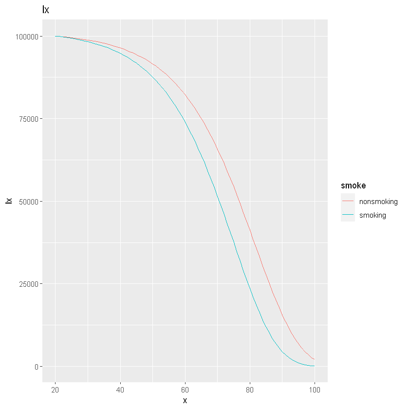

```r
ggplot(lifegraph,aes(x,lx,group=smoke,colour=smoke))+geom_line()+ggtitle("lx")
```

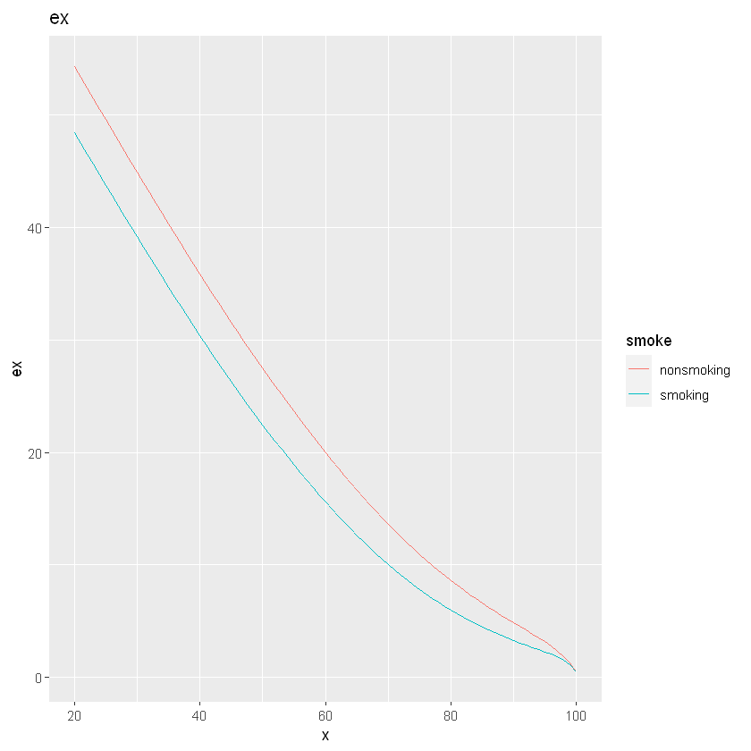

```r
ggplot(lifegraph,aes(x,ex,group=smoke,colour=smoke))+geom_line()+ggtitle("ex")
```

# Part2. Locomotive control data: 중도절단된 자료를 이용한 수명분포 추정

- Data: Locomotive Control Reliability Data - type I Censored Data
- Objective: 중도절단된(censored) 기관차 부품의 수명자료(reliability data)를 이용하여  
  부품의 수명분포를 추정하여 부품의 신뢰도(reliability)를 예측

```r
locomotive<-read.csv("locomotive.csv", header=T)
colnames(locomotive) <- c("y","tag")
locomotive<-as.tibble(locomotive) %>% mutate(lny=log(y))
```

## (a) Histogram about complete data

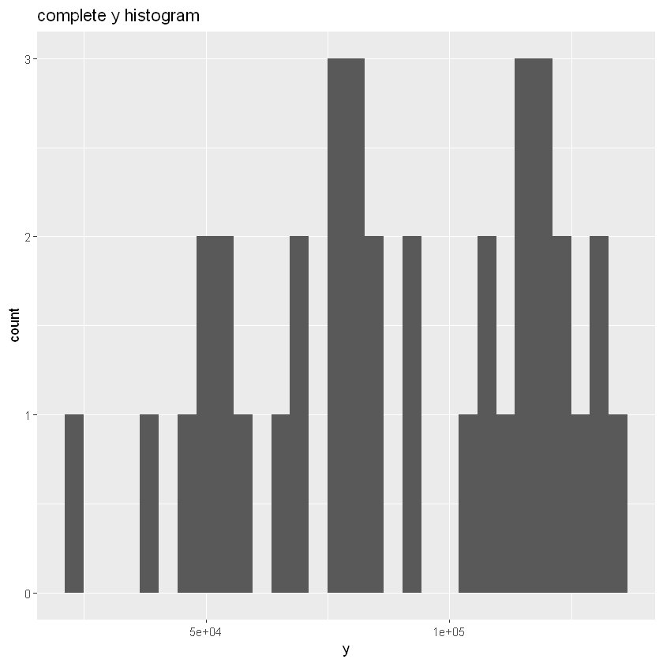

```r
ggplot(locomotive %>% filter(tag==1),aes(y))+geom_histogram()+ggtitle("complete y histogram")
```

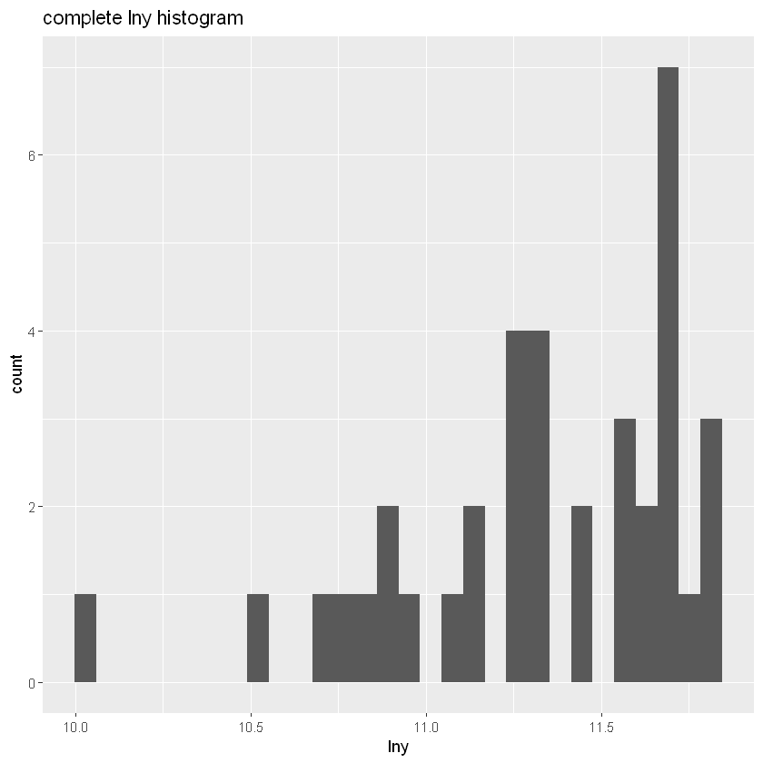

```r
ggplot(locomotive %>% filter(tag==1),aes(lny))+geom_histogram()+ggtitle("complete lny histogram")
```

## (b) Q-Q Plot & 모수 추정

```r
locomotive<-locomotive %>% filter(tag==1) %>% mutate(r=rank(y))
locomotive<-locomotive %>% mutate(pr=r/(nrow(locomotive)+1),gompit=log(-log(1-pr)),probit=qnorm(pr),gumbel=-log(-log(pr)))
```

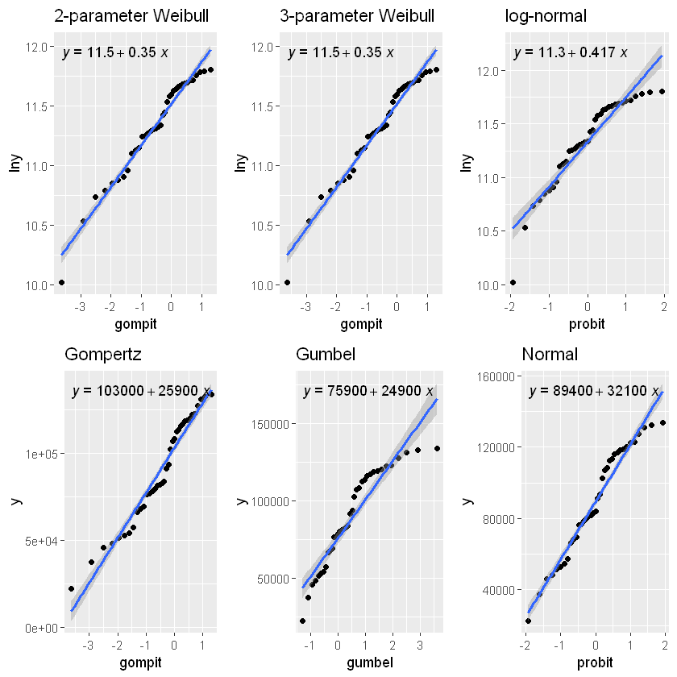

```r
# 2-parameter Weibull
qq.2.weibull <- ggplot(locomotive,aes(x=gompit,y=lny))+
  geom_point()+
  geom_smooth(method = lm)+
  stat_poly_eq(parse=T, aes(label=..eq.label..), formula=y~x)+
  labs(title="2-parameter Weibull")


# 3-parameter Weibull
qq.3.weibull <- ggplot(locomotive,aes(x=gompit,y=lny))+
  geom_point()+
  geom_smooth(method = lm)+
  stat_poly_eq(parse=T, aes(label=..eq.label..), formula=y~x)+
  labs(title="3-parameter Weibull")


# log-normal
qq.log.normal <- ggplot(locomotive,aes(x=probit,y=lny))+
  geom_point()+
  geom_smooth(method = lm)+
  stat_poly_eq(parse=T, aes(label=..eq.label..), formula=y~x)+
  labs(title="log-normal")


# Gompertz
qq.gompertz <- ggplot(locomotive,aes(x=gompit,y=y))+
  geom_point()+
  geom_smooth(method = lm)+
  stat_poly_eq(parse=T, aes(label=..eq.label..), formula=y~x)+
  labs(title="Gompertz")


# Gumbel
qq.gumbel <- ggplot(locomotive,aes(x=gumbel,y=y))+
  geom_point()+
  geom_smooth(method = lm)+
  stat_poly_eq(parse=T, aes(label=..eq.label..), formula=y~x)+
  labs(title="Gumbel")


# Normal
qq.normal <- ggplot(locomotive,aes(x=probit,y=y))+
  geom_point()+
  geom_smooth(method = lm)+
  stat_poly_eq(parse=T, aes(label=..eq.label..), formula=y~x)+
  labs(title="Normal")


grid.arrange(grobs = list(qq.2.weibull,qq.3.weibull,qq.log.normal,qq.gompertz,qq.gumbel,qq.normal),
             ncol = 3)
```

```r
R.squared<- as.matrix(c(summary(lm(lny~gompit, data=locomotive))$r.squared,
                        summary(lm(log(y-3)~gompit, data=locomotive))$r.squared,
                        summary(lm(lny~probit, data=locomotive))$r.squared,
                        summary(lm(y~gompit, data=locomotive))$r.squared,
                        summary(lm(y~gumbel, data=locomotive))$r.squared,
                        summary(lm(y~probit, data=locomotive))$r.squared))

colnames(R.squared) <- c("R-squared")
rownames(R.squared) <- c("2.par.weibull","3.par.weibull","log-normal",
                         "gompertz","gumbel","normal")
R.squared
```

|  | R-squared |
| --- | --- |
| 2.par.weibull | 0.9717623 |
| 3.par.weibull | 0.9717594 |
| log-normal | 0.8971621 |
| gompertz | 0.9615082 |
| gumbel | 0.8870621 |
| normal | 0.9649207 |

## (c) 모수의 MLE & AIC

```r
# mu, sigma

# 2-parameter Weibull
lm1<-lm(lny~gompit,data=locomotive)
mu1<-lm1$coefficients[[1]]
s1<-lm1$coefficients[[2]]

# log-normal
lm3<-lm(lny~probit,data=locomotive)
mu3<-lm3$coefficients[[1]]
s3<-lm3$coefficients[[2]]

# Gompertz
lm4<-lm(y~gompit,data=locomotive)
mu4<-lm4$coefficients[[1]]
s4<-lm4$coefficients[[2]]

# Gumbel
lm5<-lm(y~gumbel,data=locomotive)
mu5<-lm5$coefficients[[1]]
s5<-lm5$coefficients[[2]]

# Normal
lm6<-lm(y~probit,data=locomotive)
mu6<-lm6$coefficients[[1]]
s6<-lm6$coefficients[[2]]
r6<-summary(lm6)$r.squared

# 3-parameter Weibull
mylm<-function(a) {
  locomotive<-locomotive %>% mutate(weibull3=log(y-a))
  lm2<-lm(weibull3~gompit,data=locomotive)
  intercept<-as.numeric(format(summary(lm2)$coefficients[1],digits=3))
  slope<-as.numeric(format(summary(lm2)$coefficients[2],digits=3))
  r2<-summary(lm2)$r.squared
  return(list(r2,intercept,slope))
}

a<-seq(0,10000,by=100)
Rsquared<-rep(NA,length(a))

for (i in 1:length(a)) {
  Rsquared[i]<-mylm(a[i])[[1]]
}

a2<-a[which.max(Rsquared)]

locomotive<-locomotive %>% mutate(weibull=log(y-a2))
lm2<-lm(weibull~gompit,data=locomotive)
mu2<-lm2$coefficients[[1]]
s2<-lm2$coefficients[[2]]
```

```r
# MLE

# 2-parameter Weibull
weibull2<-function(v) {
  u<-(locomotive$lny-v[1])/v[2]
  g0<-exp(u-exp(u))
  G0<-1-exp(-exp(u))
  sum(log((g0/v[2]/locomotive$y)^locomotive$tag*(1-G0)^(1-locomotive$tag)))
}

# 3-parameter Weibull
weibull3<-function(v) {
  locomotive<-locomotive %>% mutate(weibullq=log(y-v[3]))
  u<-(locomotive$weibullq-v[1])/v[2]
  g0<-exp(u-exp(u))
  G0<-1-exp(-exp(u))
  sum(log((g0/(v[2]*(locomotive$y-v[3])))^locomotive$tag*(1-G0)^(1-locomotive$tag)))
}

# log-normal
lognormal<-function(v) {
  u<-(locomotive$lny-v[1])/v[2]
  g0<-dnorm(u)
  G0<-pnorm(u)
  sum(log((g0/v[2]/locomotive$y)^locomotive$tag*(1-G0)^(1-locomotive$tag)))
}

# Gompertz
gompertz<-function(v) {
  u<-(locomotive$y-v[1])/v[2]
  g0<-exp(u-exp(u))
  G0<-1-exp(-exp(u))
  sum(log((g0/v[2])^locomotive$tag*(1-G0)^(1-locomotive$tag)))
}

# Gumbel
gumbel<-function(v) {
  u<-(locomotive$y-v[1])/v[2]
  g0<-exp(-u-exp(-u))
  G0<-exp(-exp(-u))
  sum(log((g0/v[2])^locomotive$tag*(1-G0)^(1-locomotive$tag)))
}

# Normal
normal<-function(v) {
  u<-(locomotive$y-v[1])/v[2]
  g0<-dnorm(u)
  G0<-pnorm(u)
  sum(log((g0/v[2])^locomotive$tag*(1-G0)^(1-locomotive$tag)))
}
```

```r
result.2weibull<-suppressWarnings(optimx(par=c(mu1,s1),weibull2,control=list(all.methods=T,maximize=T,save.failures=T,trace=0)))
result.3weibull<-suppressWarnings(optimx(par=c(mu2,s2,a2),weibull3,control=list(all.methods=T,maximize=T,save.failures=T,trace=0)))
result.lognormal<-suppressWarnings(optimx(par=c(mu3,s3),lognormal,control=list(all.methods=T,maximize=T,save.failures=T,trace=0)))
result.gompertz<-suppressWarnings(optimx(par=c(mu4,s4),gompertz,control=list(all.methods=T,maximize=T,save.failures=T,trace=0)))
result.gumbel<-suppressWarnings(optimx(par=c(mu5,s5),gumbel,control=list(all.methods=T,maximize=T,save.failures=T,trace=0)))
result.normal<-suppressWarnings(optimx(par=c(mu6,s6),normal,control=list(all.methods=T,maximize=T,save.failures=T,trace=0)))
```

```
Maximizing -- use negfn and neggr
Maximizing -- use negfn and neggr
Maximizing -- use negfn and neggr
Maximizing -- use negfn and neggr
Maximizing -- use negfn and neggr
Maximizing -- use negfn and neggr
```

```r
mle.aic <- cbind(c(0,result.3weibull[3,3],0,0,0,0),
               c(result.2weibull[3,1],result.3weibull[3,1],result.lognormal[3,1],result.gompertz[3,1],result.gumbel[1,1],result.normal[3,1]),
               c(result.2weibull[3,2],result.3weibull[3,2],result.lognormal[3,2],result.gompertz[3,2],result.gumbel[1,2],result.normal[3,2]),
               c(-2*result.2weibull$value[1],-2*result.3weibull$value[1],-2*result.lognormal$value[1],-2*result.gompertz$value[1],-2*result.gumbel$value[1],-2*result.normal$value[1]),
               c(4,6,4,4,4,4))
```

```r
AIC <- mle.aic[,4]+mle.aic[,5]
mle.aic <- cbind(mle.aic,AIC)
colnames(mle.aic) <- c("a","mu","sigma","-2*l","2p","AIC")
rownames(mle.aic) <- c("2-Weibull","3-Weibull","log-normal","Gompertz","Gumbel","Normal")
mle.aic
```

|  | a | mu | sigma | -2*l | 2p | AIC |
| --- | --- | --- | --- | --- | --- | --- |
| 2-Weibull | 0.000000 | 11.50974 | 2.913957e-01 | 866.7587 | 4 | 870.7587 |
| 3-Weibull | 1.393179 | 11.50981 | 2.912623e-01 | 866.7587 | 6 | 872.7587 |
| log-normal | 0.000000 | 11.33044 | 4.032675e-01 | 876.2248 | 4 | 880.2248 |
| Gompertz | 0.000000 | 103901.87026 | 2.534917e+04 | 866.7827 | 4 | 870.7827 |
| Gumbel | 0.000000 | 75917.46132 | 2.487267e+04 | 877.3643 | 4 | 881.3643 |
| Normal | 0.000000 | 89397.61822 | 2.993899e+04 | 868.0757 | 4 | 872.0757 |

## (d) 적절한 수명분포를 통해 기관차 부품의 수명 추정

```r
# Model Selection: 2-parameter Weibull, Gompertz
t<-c(150000,200000,300000)
prob1<-exp(-exp((log(t)-result.2weibull[3,1])/result.2weibull[3,2]))
prob2<-exp(-exp((t-result.gompertz[3,1])/result.gompertz[3,2]))
```

```r
t.prob <- cbind(t,prob1,prob2)
colnames(t.prob) <- c("t miles", "2-parameter Weibull", "Gompertz")
t.prob
```

| t miles | 2-parameter Weibull | Gompertz |
| --- | --- | --- |
| 150000 | 1.716362e-02 | 2.106412e-03 |
| 200000 | 1.827841e-05 | 5.766270e-20 |
| 300000 | 8.904743e-20 | 0.000000e+00 |

## (e) 2-parameter Weibull

```r
library(numDeriv)
```

```r
mle.2weibull <- c(result.2weibull[3,1], result.2weibull[3,2])
J <- -hessian(weibull2,x=mle.2weibull)
V <- solve(J)
se <- sqrt(diag(V))
```

```r
# (가) theta에 대한 95% 신뢰구간
CI_mu<-c(mle.2weibull[1]-1.96*se[1],mle.2weibull[1]+1.96*se[1])
CI_sigma<-c(mle.2weibull[2]-1.96*se[2],mle.2weibull[2]+1.96*se[2])

CI <- rbind(CI_mu,CI_sigma)
colnames(CI) <- c("lower", "upper")
rownames(CI) <- c("mu", "sigma")
```

```r
CI
```

|  | lower | upper |
| --- | --- | --- |
| mu | 11.4112556 | 11.6082161 |
| sigma | 0.2137123 | 0.3690791 |

# Part3. Stature-Long bones data: 유골의 팔다리뼈 길이를 이용한 키 추정

- Data: Forensic Anthropology Data Bank
- Objective: 사망자의 유골 (두개골 및 팔다리뼈 등) 자료를 근거로  
  사망자의 성별/종족/키/나이 등을 추정

```r
fdb <- read.csv("FDB.csv", header=T)
colnames(fdb) <- c("gender", "stature", "humerus", "radius", "ulna", "femur", "tibia", "fibula")
fdb_f<-as.tibble(fdb) %>% filter(gender==0) %>% select(-gender)
```

## (a) 최적 선형모형 Hp

```r
# Full model
m1 <- lm(stature ~ . , data=fdb_f)
summary(m1)
```

```
Call:
lm(formula = stature ~ ., data = fdb_f)

Residuals:
     Min       1Q   Median       3Q      Max
-10.6669  -2.0854  -0.5879   2.7947   7.7160

Coefficients:
             Estimate Std. Error t value Pr(>|t|)
(Intercept) 30.334254  16.314471   1.859 0.071914 .
humerus      0.180460   0.084500   2.136 0.040222 *
radius      -0.147806   0.206191  -0.717 0.478517
ulna         0.003714   0.179892   0.021 0.983652
femur        0.265270   0.062619   4.236 0.000171 ***
tibia       -0.189545   0.134845  -1.406 0.169174
fibula       0.176191   0.137682   1.280 0.209576
---
Signif. codes:  0 '***' 0.001 '**' 0.01 '*' 0.05 '.' 0.1 ' ' 1

Residual standard error: 4.419 on 33 degrees of freedom
Multiple R-squared:  0.7222,	Adjusted R-squared:  0.6717
F-statistic:  14.3 on 6 and 33 DF,  p-value: 5.852e-08
```

```r
# p=5 : p-value 가장 큰 ulna 제거
p5 <- lm(stature~humerus+radius+femur+tibia+fibula,data=fdb_f)
summary(p5)
```

```
Call:
lm(formula = stature ~ humerus + radius + femur + tibia + fibula,
    data = fdb_f)

Residuals:
     Min       1Q   Median       3Q      Max
-10.6671  -2.0713  -0.5995   2.8013   7.7216

Coefficients:
            Estimate Std. Error t value Pr(>|t|)
(Intercept) 30.39766   15.78559   1.926   0.0625 .
humerus      0.18050    0.08323   2.169   0.0372 *
radius      -0.14392    0.08352  -1.723   0.0939 .
femur        0.26490    0.05916   4.478 8.08e-05 ***
tibia       -0.18994    0.13150  -1.444   0.1578
fibula       0.17691    0.13123   1.348   0.1865
---
Signif. codes:  0 '***' 0.001 '**' 0.01 '*' 0.05 '.' 0.1 ' ' 1

Residual standard error: 4.354 on 34 degrees of freedom
Multiple R-squared:  0.7222,	Adjusted R-squared:  0.6813
F-statistic: 17.68 on 5 and 34 DF,  p-value: 1.299e-08
```

```r
# p=4 : p-value 가장 큰 fibula 제거
p4 <- lm(stature~humerus+radius+femur+tibia,data=fdb_f)
summary(p4)
```

```
Call:
lm(formula = stature ~ humerus + radius + femur + tibia, data = fdb_f)

Residuals:
     Min       1Q   Median       3Q      Max
-12.4321  -2.4037   0.0637   2.6865   7.8720

Coefficients:
            Estimate Std. Error t value Pr(>|t|)
(Intercept) 34.13910   15.72013   2.172   0.0367 *
humerus      0.15948    0.08270   1.928   0.0619 .
radius      -0.11815    0.08225  -1.437   0.1597
femur        0.28227    0.05841   4.832 2.66e-05 ***
tibia       -0.04729    0.07898  -0.599   0.5532
---
Signif. codes:  0 '***' 0.001 '**' 0.01 '*' 0.05 '.' 0.1 ' ' 1

Residual standard error: 4.404 on 35 degrees of freedom
Multiple R-squared:  0.7073,	Adjusted R-squared:  0.6739
F-statistic: 21.15 on 4 and 35 DF,  p-value: 6.134e-09
```

```r
# p=3 : p-value 가장 큰 tibia 제거
p3 <- lm(stature~humerus+radius+femur,data=fdb_f)
summary(p3)
```

```
Call:
lm(formula = stature ~ humerus + radius + femur, data = fdb_f)

Residuals:
     Min       1Q   Median       3Q      Max
-12.5895  -2.4649   0.2548   2.7146   7.7324

Coefficients:
            Estimate Std. Error t value Pr(>|t|)
(Intercept) 35.56903   15.39865   2.310   0.0267 *
humerus      0.14197    0.07666   1.852   0.0723 .
radius      -0.13326    0.07758  -1.718   0.0945 .
femur        0.26008    0.04474   5.813 1.24e-06 ***
---
Signif. codes:  0 '***' 0.001 '**' 0.01 '*' 0.05 '.' 0.1 ' ' 1

Residual standard error: 4.365 on 36 degrees of freedom
Multiple R-squared:  0.7043,	Adjusted R-squared:  0.6797
F-statistic: 28.59 on 3 and 36 DF,  p-value: 1.235e-09
```

```r
# p=2 : p-value 가장 큰 radius 제거
p2 <- lm(stature~humerus+femur,data=fdb_f)
summary(p2)
```

```
Call:
lm(formula = stature ~ humerus + femur, data = fdb_f)

Residuals:
     Min       1Q   Median       3Q      Max
-14.7241  -1.8793   0.1595   2.3830   7.7724

Coefficients:
            Estimate Std. Error t value Pr(>|t|)
(Intercept) 37.56673   15.75410   2.385   0.0223 *
humerus      0.08003    0.06941   1.153   0.2563
femur        0.22844    0.04183   5.461 3.38e-06 ***
---
Signif. codes:  0 '***' 0.001 '**' 0.01 '*' 0.05 '.' 0.1 ' ' 1

Residual standard error: 4.478 on 37 degrees of freedom
Multiple R-squared:  0.6801,	Adjusted R-squared:  0.6628
F-statistic: 39.33 on 2 and 37 DF,  p-value: 6.957e-10
```

```r
# p=1 : p-value 가장 큰 humerus 제거
p1 <- lm(stature~femur,data=fdb_f)
summary(p1)
```

```
Call:
lm(formula = stature ~ femur, data = fdb_f)

Residuals:
     Min       1Q   Median       3Q      Max
-14.3093  -1.9048   0.1493   2.5385   9.2152

Coefficients:
            Estimate Std. Error t value Pr(>|t|)
(Intercept) 47.35377   13.32901   3.553  0.00104 **
femur        0.26227    0.02995   8.756  1.2e-10 ***
---
Signif. codes:  0 '***' 0.001 '**' 0.01 '*' 0.05 '.' 0.1 ' ' 1

Residual standard error: 4.498 on 38 degrees of freedom
Multiple R-squared:  0.6686,	Adjusted R-squared:  0.6599
F-statistic: 76.67 on 1 and 38 DF,  p-value: 1.195e-10
```

```r
AIC.H <- matrix(c(seq(1:6),AIC(p1),AIC(p2),AIC(p3),AIC(p4),AIC(p5),AIC(m1)),6,2)
colnames(AIC.H) <- c("p", "AIC")
AIC.H
```

| p | AIC |
| --- | --- |
| 1 | 237.7462 |
| 2 | 238.3343 |
| 3 | 237.1838 |
| 4 | 238.7761 |
| 5 | 238.6931 |
| 6 | 240.6926 |

p=3일 때, AIC 값이 가장 작으므로 최적 선형모형이다.

## (b) AIC 그래프

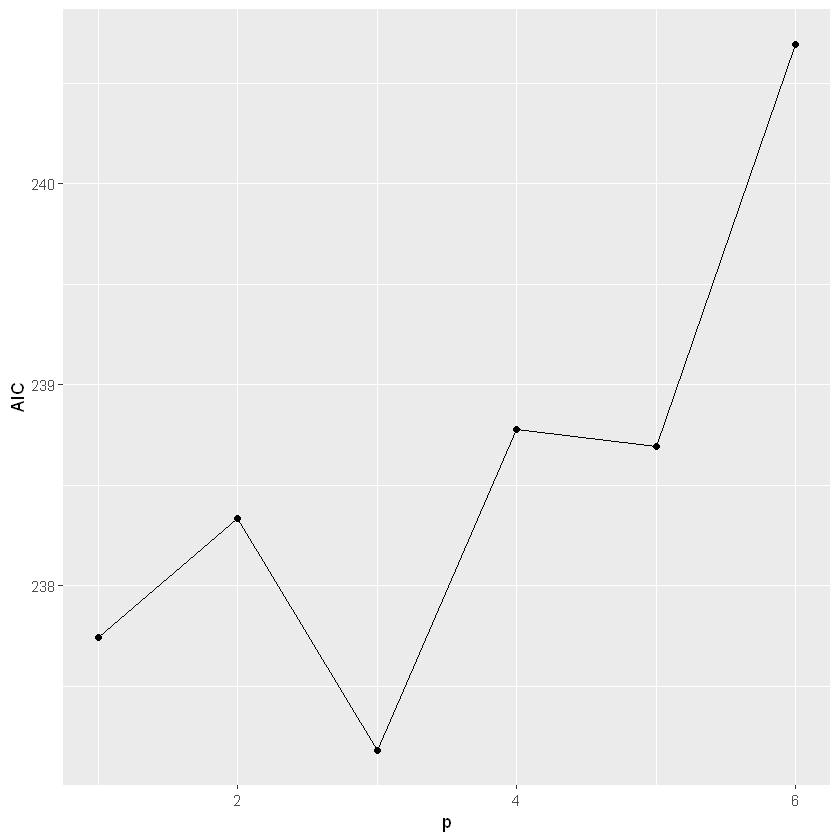

```r
AIC.H <- as.data.frame(AIC.H)
ggplot(AIC.H, aes(x=AIC.H$p,y=AIC.H$AIC))+geom_point()+geom_line()+xlab("p")+ylab("AIC")
```

p=3일 때, AIC 값이 가장 작으므로 최적 선형모형이다.

## (c) 키 예측

```r
p3.c <- lm(stature~humerus+radius+tibia,data=fdb_f)
summary(p3.c)
```

```
Call:
lm(formula = stature ~ humerus + radius + tibia, data = fdb_f)

Residuals:
    Min      1Q  Median      3Q     Max
-14.543  -3.399   1.786   3.635   9.194

Coefficients:
            Estimate Std. Error t value Pr(>|t|)
(Intercept) 54.96489   19.24731   2.856  0.00709 **
humerus      0.17680    0.10519   1.681  0.10148
radius      -0.07514    0.10410  -0.722  0.47506
tibia        0.19489    0.07771   2.508  0.01679 *
---
Signif. codes:  0 '***' 0.001 '**' 0.01 '*' 0.05 '.' 0.1 ' ' 1

Residual standard error: 5.607 on 36 degrees of freedom
Multiple R-squared:  0.5121,	Adjusted R-squared:  0.4714
F-statistic: 12.59 on 3 and 36 DF,  p-value: 8.802e-06
```

최적 방정식: stature = 54.9649 + 0.1768 *humerus + (-0.0751)* radius + 0.1949 * tibia

```r
new <- data.frame(humerus=324,radius=245,tibia=372)
predict(p3.c, newdata = new, interval = "prediction")
```

| fit | lwr | upr |
| --- | --- | --- |
| 166.338 | 154.5363 | 178.1397 |

CI에 172.72가 포함되므로, 유골의 주인공의 키가 172.7cm일 가능성이 있고, 주인공이 Amelia Earhart일 가능성이 있다.

## (d) 남자의 최적모형

```r
fdb_m<-as.tibble(fdb) %>% filter(gender==1) %>% select(-gender)
```

```r
# Full model
m1.m <- lm(stature ~ . , data=fdb_m)
summary(m1.m)
```

```
Call:
lm(formula = stature ~ ., data = fdb_m)

Residuals:
     Min       1Q   Median       3Q      Max
-10.6354  -3.7770   0.6665   3.1470  13.3561

Coefficients:
            Estimate Std. Error t value Pr(>|t|)
(Intercept) 68.75942   16.23349   4.236  0.00013 ***
humerus     -0.01744    0.08445  -0.207  0.83743
radius      -0.10607    0.19297  -0.550  0.58561
ulna         0.13842    0.19319   0.716  0.47785
femur        0.12082    0.07267   1.663  0.10420
tibia       -0.04408    0.13950  -0.316  0.75366
fibula       0.16151    0.12916   1.250  0.21840
---
Signif. codes:  0 '***' 0.001 '**' 0.01 '*' 0.05 '.' 0.1 ' ' 1

Residual standard error: 5.533 on 40 degrees of freedom
Multiple R-squared:  0.6045,	Adjusted R-squared:  0.5452
F-statistic: 10.19 on 6 and 40 DF,  p-value: 7.875e-07
```

```r
# p=5 : p-value 가장 큰 humerus 제거
p5.m <- lm(stature~radius+ulna+femur+tibia+fibula,data=fdb_m)
summary(p5.m)
```

```
Call:
lm(formula = stature ~ radius + ulna + femur + tibia + fibula,
    data = fdb_m)

Residuals:
    Min      1Q  Median      3Q     Max
-10.906  -3.821   0.604   3.126  13.433

Coefficients:
            Estimate Std. Error t value Pr(>|t|)
(Intercept) 68.01491   15.64230   4.348 8.86e-05 ***
radius      -0.10504    0.19064  -0.551    0.585
ulna         0.12862    0.18507   0.695    0.491
femur        0.11398    0.06392   1.783    0.082 .
tibia       -0.04757    0.13684  -0.348    0.730
fibula       0.16640    0.12547   1.326    0.192
---
Signif. codes:  0 '***' 0.001 '**' 0.01 '*' 0.05 '.' 0.1 ' ' 1

Residual standard error: 5.468 on 41 degrees of freedom
Multiple R-squared:  0.6041,	Adjusted R-squared:  0.5558
F-statistic: 12.51 on 5 and 41 DF,  p-value: 2.112e-07
```

```r
# p=4 : p-value 가장 큰 tibia 제거
p4.m <- lm(stature~radius+ulna+femur+fibula,data=fdb_m)
summary(p4.m)
```

```
Call:
lm(formula = stature ~ radius + ulna + femur + fibula, data = fdb_m)

Residuals:
     Min       1Q   Median       3Q      Max
-10.8744  -3.6392   0.5132   3.3204  13.5903

Coefficients:
            Estimate Std. Error t value Pr(>|t|)
(Intercept) 69.37208   14.98787   4.629 3.52e-05 ***
radius      -0.10981    0.18815  -0.584   0.5626
ulna         0.11586    0.17949   0.646   0.5221
femur        0.11075    0.06258   1.770   0.0840 .
fibula       0.13064    0.07109   1.838   0.0732 .
---
Signif. codes:  0 '***' 0.001 '**' 0.01 '*' 0.05 '.' 0.1 ' ' 1

Residual standard error: 5.411 on 42 degrees of freedom
Multiple R-squared:  0.6029,	Adjusted R-squared:  0.5651
F-statistic: 15.94 on 4 and 42 DF,  p-value: 5.153e-08
```

```r
# p=3 : p-value 가장 큰 radius 제거
p3.m <- lm(stature~ulna+femur+fibula,data=fdb_m)
summary(p3.m)
```

```
Call:
lm(formula = stature ~ ulna + femur + fibula, data = fdb_m)

Residuals:
     Min       1Q   Median       3Q      Max
-10.6834  -3.7329   0.2486   3.3460  14.8635

Coefficients:
            Estimate Std. Error t value Pr(>|t|)
(Intercept) 71.02026   14.60614   4.862 1.59e-05 ***
ulna         0.02940    0.10056   0.292   0.7714
femur        0.09975    0.05921   1.685   0.0993 .
fibula       0.12830    0.07043   1.822   0.0755 .
---
Signif. codes:  0 '***' 0.001 '**' 0.01 '*' 0.05 '.' 0.1 ' ' 1

Residual standard error: 5.369 on 43 degrees of freedom
Multiple R-squared:  0.5997,	Adjusted R-squared:  0.5718
F-statistic: 21.47 on 3 and 43 DF,  p-value: 1.183e-08
```

```r
# p=2 : p-value 가장 큰 ulna 제거
p2.m <- lm(stature~femur+fibula,data=fdb_m)
summary(p2.m)
```

```
Call:
lm(formula = stature ~ femur + fibula, data = fdb_m)

Residuals:
     Min       1Q   Median       3Q      Max
-10.4573  -3.6160   0.2168   3.3979  14.9446

Coefficients:
            Estimate Std. Error t value Pr(>|t|)
(Intercept) 72.80126   13.13618   5.542 1.58e-06 ***
femur        0.10567    0.05504   1.920   0.0614 .
fibula       0.13731    0.06267   2.191   0.0338 *
---
Signif. codes:  0 '***' 0.001 '**' 0.01 '*' 0.05 '.' 0.1 ' ' 1

Residual standard error: 5.313 on 44 degrees of freedom
Multiple R-squared:  0.5989,	Adjusted R-squared:  0.5807
F-statistic: 32.85 on 2 and 44 DF,  p-value: 1.869e-09
```

```r
# p=1 : p-value 가장 큰 femur 제거
p1.m <- lm(stature~fibula,data=fdb_m)
summary(p1.m)
```

```
Call:
lm(formula = stature ~ fibula, data = fdb_m)

Residuals:
     Min       1Q   Median       3Q      Max
-11.2043  -4.0384   0.2262   3.5715  15.8764

Coefficients:
            Estimate Std. Error t value Pr(>|t|)
(Intercept) 82.35679   12.51420   6.581 4.27e-08 ***
fibula       0.24215    0.03165   7.650 1.12e-09 ***
---
Signif. codes:  0 '***' 0.001 '**' 0.01 '*' 0.05 '.' 0.1 ' ' 1

Residual standard error: 5.469 on 45 degrees of freedom
Multiple R-squared:  0.5653,	Adjusted R-squared:  0.5556
F-statistic: 58.52 on 1 and 45 DF,  p-value: 1.12e-09
```

```r
AIC.H.m <- matrix(c(seq(1:6),AIC(p1.m),AIC(p2.m),AIC(p3.m),AIC(p4.m),AIC(p5.m),AIC(m1.m)),6,2)
colnames(AIC.H.m) <- c("p", "AIC")
AIC.H.m
```

| p | AIC |
| --- | --- |
| 1 | 297.0543 |
| 2 | 295.2736 |
| 3 | 297.1803 |
| 4 | 298.8006 |
| 5 | 300.6623 |
| 6 | 302.6122 |

p=2일 때, AIC 값이 가장 작으므로 최적 선형모형이다.

## (e) 교호작용 고려한 최적 방정식

```r
library(leaps)
```

```r
dat.e <- data.frame(Gender=fdb$Gender,fdb[,2:8],
                    g.Humerus=fdb$Gender*fdb$Humerus,
                    g.Radius=fdb$Gender*fdb$Radius,
                    g.Ulna=fdb$Gender*fdb$Ulna,
                    g.Femur=fdb$Gender*fdb$Femur,
                    g.Tibia=fdb$Gender*fdb$Tibia,
                    g.Fibula=fdb$Gender*fdb$Fibula)
```

```r
x <- as.matrix(dat.e[,2:14])
y <- dat.e$Stature
m1 <- regsubsets(Stature~.,data=dat.e,nvmax=99999)
summary(m1)
```

```
Subset selection object
Call: regsubsets.formula(Stature ~ ., data = dat.e, nvmax = 99999)
13 Variables  (and intercept)
          Forced in Forced out
Gender        FALSE      FALSE
Humerus       FALSE      FALSE
Radius        FALSE      FALSE
Ulna          FALSE      FALSE
Femur         FALSE      FALSE
Tibia         FALSE      FALSE
Fibula        FALSE      FALSE
g.Humerus     FALSE      FALSE
g.Radius      FALSE      FALSE
g.Ulna        FALSE      FALSE
g.Femur       FALSE      FALSE
g.Tibia       FALSE      FALSE
g.Fibula      FALSE      FALSE
1 subsets of each size up to 13
Selection Algorithm: exhaustive
          Gender Humerus Radius Ulna Femur Tibia Fibula g.Humerus g.Radius
1  ( 1 )  " "    " "     " "    " "  "*"   " "   " "    " "       " "
2  ( 1 )  " "    " "     " "    " "  "*"   " "   " "    " "       " "
3  ( 1 )  " "    " "     " "    " "  "*"   " "   " "    " "       " "
4  ( 1 )  "*"    " "     " "    " "  "*"   " "   " "    " "       " "
5  ( 1 )  "*"    " "     "*"    " "  "*"   " "   " "    " "       " "
6  ( 1 )  "*"    "*"     "*"    " "  "*"   " "   " "    " "       " "
7  ( 1 )  "*"    "*"     "*"    " "  "*"   " "   " "    "*"       " "
8  ( 1 )  "*"    "*"     "*"    " "  "*"   " "   " "    "*"       " "
9  ( 1 )  "*"    "*"     "*"    " "  "*"   "*"   " "    "*"       " "
10  ( 1 ) "*"    "*"     "*"    " "  "*"   "*"   "*"    "*"       " "
11  ( 1 ) "*"    "*"     "*"    " "  "*"   "*"   "*"    "*"       "*"
12  ( 1 ) "*"    "*"     "*"    " "  "*"   "*"   "*"    "*"       "*"
13  ( 1 ) "*"    "*"     "*"    "*"  "*"   "*"   "*"    "*"       "*"
          g.Ulna g.Femur g.Tibia g.Fibula
1  ( 1 )  " "    " "     " "     " "
2  ( 1 )  " "    " "     " "     "*"
3  ( 1 )  " "    "*"     " "     "*"
4  ( 1 )  " "    "*"     " "     "*"
5  ( 1 )  " "    "*"     " "     "*"
6  ( 1 )  " "    "*"     " "     "*"
7  ( 1 )  " "    "*"     " "     "*"
8  ( 1 )  "*"    "*"     " "     "*"
9  ( 1 )  "*"    "*"     " "     "*"
10  ( 1 ) "*"    "*"     "*"     " "
11  ( 1 ) "*"    "*"     "*"     " "
12  ( 1 ) "*"    "*"     "*"     "*"
13  ( 1 ) "*"    "*"     "*"     "*"
```

```r
p1.e  <- lm(Stature~Gender,data=dat.e)
p2.e  <- lm(Stature~Gender+g.Radius,data=dat.e)
p3.e  <- lm(Stature~Gender+g.Humerus+g.Radius,data=dat.e)
p4.e  <- lm(Stature~Gender+Fibula+g.Humerus+g.Radius,data=dat.e)
p5.e  <- lm(Stature~Gender+Ulna+g.Femur+g.Tibia+g.Fibula,data=dat.e)
p6.e  <- lm(Stature~Gender+Ulna+g.Humerus+g.Radius+g.Ulna+g.Fibula,data=dat.e)
p7.e  <- lm(Stature~Gender+Ulna+g.Humerus+g.Radius+g.Ulna+g.Femur+g.Fibula,data=dat.e)
p8.e  <- lm(Stature~Gender+Ulna+Fibula+g.Humerus+g.Radius+g.Ulna+g.Femur+g.Fibula,data=dat.e)
p9.e  <- lm(Stature~Gender+Ulna+Femur+Fibula+g.Humerus+g.Radius+g.Ulna+g.Femur+g.Fibula,data=dat.e)
p10.e <- lm(Stature~Gender+Radius+Ulna+Femur+Fibula+g.Humerus+g.Radius+g.Ulna+g.Femur+g.Fibula,data=dat.e)
p11.e <- lm(Stature~Gender+Humerus+Radius+Ulna+Femur+Fibula+g.Humerus+g.Radius+g.Ulna+g.Femur+g.Fibula,data=dat.e)
p12.e <- lm(Stature~Gender+Humerus+Radius+Ulna+Femur+Tibia+Fibula+g.Humerus+g.Radius+g.Ulna+g.Femur+g.Fibula,data=dat.e)
p13.e <- lm(Stature~Gender+Humerus+Radius+Ulna+Femur+Tibia+Fibula+g.Humerus+g.Radius+g.Ulna+g.Femur+g.Tibia+g.Fibula,data=dat.e)
```

```r
matrix.e <- matrix(c(AIC(p1.e),AIC(p2.e),AIC(p3.e),AIC(p4.e),
                     AIC(p5.e),AIC(p6.e),AIC(p7.e),AIC(p8.e),
                     AIC(p9.e),AIC(p10.e),AIC(p11.e),AIC(p12.e),AIC(p13.e)),13,1)
colnames(matrix.e) <- c("AIC")
rownames(matrix.e) <- c("H1","H2","H3","H4","H5","H6",
                        "H7","H8","H9","H10","H11","H12","H13")
matrix.e
```

|  | AIC |
| --- | --- |
| H1 | 612.3112 |
| H2 | 588.1038 |
| H3 | 588.9585 |
| H4 | 551.0392 |
| H5 | 571.7359 |
| H6 | 574.0040 |
| H7 | 573.6567 |
| H8 | 554.1369 |
| H9 | 540.6579 |
| H10 | 542.3441 |
| H11 | 541.6649 |
| H12 | 542.3743 |
| H13 | 543.7479 |

p=9일 때, AIC 값이 가장 작으므로 최적 선형모형이다.

```r
summary(p9.e)
```

```
Call:
lm(formula = Stature ~ Gender + Ulna + Femur + Fibula + g.Humerus +
    g.Radius + g.Ulna + g.Femur + g.Fibula, data = dat.e)

Residuals:
     Min       1Q   Median       3Q      Max
-13.1137  -2.6426  -0.2894   3.1488  13.4853

Coefficients:
            Estimate Std. Error t value Pr(>|t|)
(Intercept) 50.16502   15.69021   3.197 0.002014 **
Gender      19.97152   21.24408   0.940 0.350107
Ulna        -0.06825    0.08016  -0.851 0.397169
Femur        0.25624    0.06617   3.872 0.000225 ***
Fibula       0.04757    0.09173   0.519 0.605534
g.Humerus   -0.02067    0.07677  -0.269 0.788435
g.Radius    -0.11062    0.17625  -0.628 0.532123
g.Ulna       0.19684    0.19215   1.024 0.308859
g.Femur     -0.13710    0.09373  -1.463 0.147617
g.Fibula     0.08038    0.11379   0.706 0.482085
---
Signif. codes:  0 '***' 0.001 '**' 0.01 '*' 0.05 '.' 0.1 ' ' 1

Residual standard error: 5.068 on 77 degrees of freedom
Multiple R-squared:  0.795,	Adjusted R-squared:  0.7711
F-statistic: 33.18 on 9 and 77 DF,  p-value: < 2.2e-16
```